# Lab01 - Preprocesamiento de Datos

Antes de empezar a entrenar un modelo es importante **conocer los datos** para alimentar el modelo con datos que aporten valor y nos ayuden a realizar una correcta Prediccion/Clasificacion/Segmentacion. Esta actividad se conoce como **Analisis Exploratorio (EDA)**  
Vamos a analizar dos atributos importantes a la hora de definir que variables van a alimentar el modelo: - Calidad de Datos - Correlacion entre los Datos

## Configuracion

Trate de ejecutar la siguiente celda para validar que las librerias que vamos a utilizar hoy se encentran instaladas correctamente. Si no es asi, instale las librerias faltantes. Luego, vuelva a intentar cargarlas hasta que la celda se ejecute sin errores.

```r
library(dplyr)
library(skimr)
library(tidyr)
```

```r
library(ggplot2)
library(corrgram)
library(lattice)
library(car)
library(esquisse)
library(lubridate)
```

## Cargar el set de datos

Vamos a usar un set de datos del [UC Irvine Machine Learning Repository](https://archive.ics.uci.edu/ml/index.php) en donde se registran los atributos de varias botellas de vino junto con su calidad. Este dataset ha sido modificado un poco para trabajar la limpieza y calidad en este laboratorio. La version original puede descargrse [aqui](https://archive.ics.uci.edu/ml/machine-learning-databases/wine-quality/winequality-white.csv)

Vamos a cargar este dataset en este laboratorio para procesarlo y dejarlo listo para los **siguientes laboratorios** de prediccion y clasificacion. De esta forma usaremos el mismo dataset a lo largo de todo el flujo del curso como si se tratara de un proyecto real!

```r
wine_df <- read.csv('data/winequality-white.csv', sep = ';', header = T, fileEncoding = 'utf-8')
```

## Calidad de Datos

Lo primero que debemos hacer, y que parece obvio, es revisar una muestra de los datos para darnos una idea de los valores que vienen en cada columna/atributo

```r
head(wine_df) # Permite ver: dimensiones, tipos de dato y muestra
```

|  | fixed_acidity | volatile_acidity | citric_acid | residual_sugar | chlorides | free_sulfur_dioxide | total_sulfur_dioxide | density | pH | sulphates | alcohol | color | score |
| --- | --- | --- | --- | --- | --- | --- | --- | --- | --- | --- | --- | --- | --- |
| 1 | 7.0 | 0.27 | 0.36 | 20.7 | 0.045 | 45 | 170 | 1.0010 | 3.00 | 0.45 | 8.8 | 13 | 6.15 |
| 2 | 6.3 | 0.30 | 0.34 | 1.6 | 0.049 | 14 | 132 | 0.9940 | 3.30 | 0.49 | 9.5 | NA | 6.67 |
| 3 | 8.1 | 0.28 | 0.40 | 6.9 | 0.050 | 30 | 97 | 0.9951 | 3.26 | 0.44 | 10.1 | NA | 6.48 |
| 4 | 7.2 | 0.23 | 0.32 | 8.5 | 0.058 | 47 | 186 | 0.9956 | 3.19 | 0.40 | 9.9 | NA | 6.74 |
| 5 | 7.2 | 0.23 | 0.32 | 8.5 | 0.058 | 47 | 186 | 0.9956 | 3.19 | 0.40 | 9.9 | NA | 6.45 |
| 6 | 8.1 | 0.28 | 0.40 | 6.9 | 0.050 | 30 | 97 | 0.9951 | 3.26 | 0.44 | 10.1 | NA | 6.26 |

Tambien es importante conocer con anterioridad el tamaño de los datos con los que estamos tratando, esto podemos verlo en las variables de ambiente de la derecha.

Otra buena practica al iniciar el Analisis Exploratorio es validar los tipos de dato con los que estamos tratando. Esto nos permitira tratar cada atributo de la manera correspondiente o realizar las transformaciones necesarias.

```r
glimpse(wine_df) # Permite ver: dimensiones, tipos de dato y muestra
```

```
## Rows: 4,898
## Columns: 13
## $ fixed_acidity        <dbl> 7.0, 6.3, 8.1, 7.2, 7.2, 8.1, 6.2, 7.0, 6.3, 8...
## $ volatile_acidity     <dbl> 0.27, 0.30, 0.28, 0.23, 0.23, 0.28, 0.32, 0.27...
## $ citric_acid          <dbl> 0.36, 0.34, 0.40, 0.32, 0.32, 0.40, 0.16, 0.36...
## $ residual_sugar       <dbl> 20.70, 1.60, 6.90, 8.50, 8.50, 6.90, 7.00, 20....
## $ chlorides            <dbl> 0.045, 0.049, 0.050, 0.058, 0.058, 0.050, 0.04...
## $ free_sulfur_dioxide  <dbl> 45, 14, 30, 47, 47, 30, 30, 45, 14, 28, 11, 17...
## $ total_sulfur_dioxide <dbl> 170, 132, 97, 186, 186, 97, 136, 170, 132, 129...
## $ density              <dbl> 1.0010, 0.9940, 0.9951, 0.9956, 0.9956, 0.9951...
## $ pH                   <dbl> 3.00, 3.30, 3.26, 3.19, 3.19, 3.26, 3.18, 3.00...
## $ sulphates            <dbl> 0.45, 0.49, 0.44, 0.40, 0.40, 0.44, 0.47, 0.45...
## $ alcohol              <dbl> 8.8, 9.5, 10.1, 9.9, 9.9, 10.1, 9.6, 8.8, 9.5,...
## $ color                <int> 13, NA, NA, NA, NA, NA, NA, 13, NA, NA, 8, NA,...
## $ score                <dbl> 6.15, 6.67, 6.48, 6.74, 6.45, 6.26, 6.70, 6.41...
```

En este caso, todas las variables son numericas (dbl o int), lo que las hace buenas candidatas para un modelo, por ejemplo de regresion. Si se encontraran variables categoricas deberiamos hacer la validacion y transformacion de estos valores.

Ya con una idea mas clara de la estructura de datos con la que estamos tratando, realicemos un analisis matematico rapido sobre los datos:

```r
summary(wine_df)
```

```
##  fixed_acidity    volatile_acidity  citric_acid     residual_sugar
##  Min.   : 3.800   Min.   :0.0800   Min.   :0.0100   Min.   : 0.600
##  1st Qu.: 6.300   1st Qu.:0.2100   1st Qu.:0.2700   1st Qu.: 1.700
##  Median : 6.800   Median :0.2600   Median :0.3200   Median : 5.200
##  Mean   : 6.855   Mean   :0.2782   Mean   :0.3355   Mean   : 6.391
##  3rd Qu.: 7.300   3rd Qu.:0.3200   3rd Qu.:0.3900   3rd Qu.: 9.900
##  Max.   :14.200   Max.   :1.1000   Max.   :1.6600   Max.   :65.800
##                                    NA's   :19
##    chlorides       free_sulfur_dioxide total_sulfur_dioxide    density
##  Min.   :0.00900   Min.   :  2.00      Min.   :  9.0        Min.   :0.9871
##  1st Qu.:0.03600   1st Qu.: 23.00      1st Qu.:108.0        1st Qu.:0.9917
##  Median :0.04300   Median : 34.00      Median :134.0        Median :0.9937
##  Mean   :0.04577   Mean   : 35.31      Mean   :138.4        Mean   :0.9940
##  3rd Qu.:0.05000   3rd Qu.: 46.00      3rd Qu.:167.0        3rd Qu.:0.9961
##  Max.   :0.34600   Max.   :289.00      Max.   :440.0        Max.   :1.0390
##
##        pH          sulphates         alcohol          color
##  Min.   :3.000   Min.   :0.2200   Min.   : 8.00   Min.   : 8.00
##  1st Qu.:3.120   1st Qu.:0.4100   1st Qu.: 9.50   1st Qu.: 8.00
##  Median :3.210   Median :0.4700   Median :10.40   Median :13.00
##  Mean   :3.304   Mean   :0.4898   Mean   :10.51   Mean   :11.36
##  3rd Qu.:3.340   3rd Qu.:0.5500   3rd Qu.:11.40   3rd Qu.:13.00
##  Max.   :4.290   Max.   :1.0800   Max.   :14.20   Max.   :13.00
##                                                   NA's   :3593
##      score
##  Min.   :3.000
##  1st Qu.:5.700
##  Median :6.350
##  Mean   :6.368
##  3rd Qu.:6.920
##  Max.   :9.790
##
```

Esto nos entrega un resumen de las medidas de tendencia y dispercion de los atributos **numericos** de nuestro dataset:  
- Conteo de registros: Nos permite validar si algunos campos vienen Nulos (NA’s) - Promedio: Nos da una idea de la dispercion de cada atributo - Valores Minimo y Maximo: Nos permite conocer el dominio de valores entre los que se distribuye cada atributo - Cuartiles: Nos da un resumen de la distribucion de los valores y posibles atipicos

### Datos Faltantes

En R, un dato vacio o faltante es identificado con el valor *NA* (Not a Number) y debemos identificar que valores faltantes hay en cada atributo y entender su significado. Ya lo vimos en el conteo de valores de la celda anterior, pero tambien podemos verlo particularmente:

```r
colSums(is.na(wine_df))
```

```
##        fixed_acidity     volatile_acidity          citric_acid
##                    0                    0                   19
##       residual_sugar            chlorides  free_sulfur_dioxide
##                    0                    0                    0
## total_sulfur_dioxide              density                   pH
##                    0                    0                    0
##            sulphates              alcohol                color
##                    0                    0                 3593
##                score
##                    0
```

Hay dos variables que llaman nuestra atencion: *citric acid* y *color*. Que podemos hacer con estos datos? - Si son datos invalidos podemos eliminarlos: OJO, aunque esto asegura que tendremos solo registros *limpios*, tambien perderemos registros que podrian contener otra informacion util para el modelo. - Si son datos invalidos tambien podemos reemplazarlos con valor valido, por ejemplo co el promedio de los valores validos de ese mismo atributo. De esta forma conservamos la cantidad de registros y no perdemos valor para ese atributo, pero OJO: el valor de reemplazo debe tener sentido para el negocio. - Si son datos validos para el negocio, por ejemplo, se acostumbra dejar vacio cuando es valor 0, podemos hacer este reemplazo directamente para que el modelo entienda eso. OJO: En este caso se deben tener muy claras las reglas de negocio. **Este es el caso de “citric acid”** - Si son **muchos** los valores en nulo en una columna en partcular, se puede considerar no tener en cuenta ese atributo en el analisis porque no estaria aportando valor diferencial a cada muestra. **Este es el caso de “color”**

```r
wine_df['citric.acid'] <- replace(wine_df['citric_acid'],
                                  is.na(wine_df['citric_acid']),0)
```

El caso de *color* es distinto, son **muchos** los valores faltantes (3593 de 4898). Veamos que valores tienen los pocos registros que si aportan informacion

```r
sum(is.na(wine_df['color'])) # Contar valores nulos
```

```
## [1] 3593
```

```r
table(wine_df['color'])      # COntar valores no Nulos
```

```
##
##   8  13
## 428 877
```

Ademas de los 3593 valores en Nulo, se tienen 428 en valor *8* y 877 en valor *13*. Estos valores realmente no nos dicen nada, si no conocemos el significado de cada uno. Lo mejor en este caso es eliminar la columna ya que no aportaria nada al modelo, ni es algo que podamos explicar.

```r
wine_df = subset(wine_df, select = -c(color))
```

### Valores Atipicos

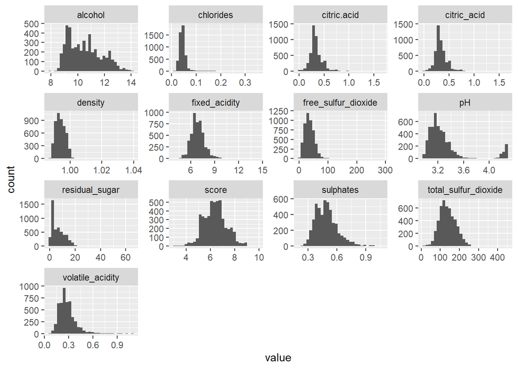

```r
wine_df %>%
  gather() %>%                       # Llave-Valor
  ggplot(aes(value)) +               # Grafica
  facet_wrap(~ key, scales="free") + # En panees diferentes
  geom_histogram()                   # Tipo de grafica
```

Esto nos permite visualizar la distribucion de cada variable, valores mas comunes y de pronto algunos atipicos. Pero la mejor forma de determinar si hay datos fuera de lo normal es con un analisis estadistico de cajas:

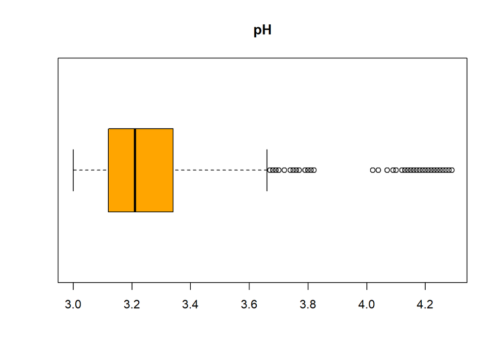

```r
boxplot(wine_df['pH'], main='pH',
        horizontal=T, col='orange')
```

Dicen los [expertos](https://www.aprenderdevino.es/ph-y-vino/), que el pH de un vino tinto varia entre 3.3 y 3.6 g/l. Éste conocimiento de negocio, asi como la grafica anterior nos permite dudar un poco de las muestras con valores superiores, por ejemplo a **4**. *Este valor puede variar como consideremos conveniente. No se recomienda cortar estrictamente en el intervalo que dicta la regla de negocio (3.3 - 3.6) pues algunos atipicos cercanos pueden ser posibles enla naturaleza*

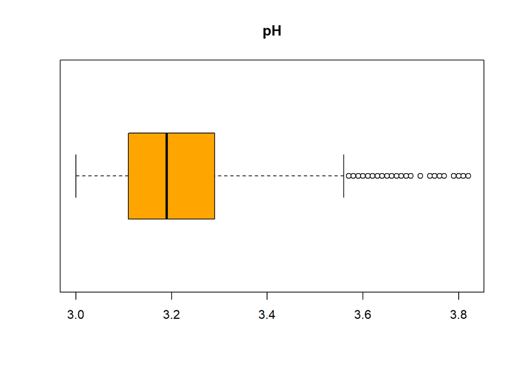

```r
wine_df <- wine_df %>%
  filter(pH < 4)

boxplot(wine_df['pH'], main='pH',
        horizontal=T, col='orange')
```

```r
# Resumen estadistico (Otra forma)
skim(wine_df)
```

Data summary

| Name | wine_df |
| --- | --- |
| Number of rows | 4461 |
| Number of columns | 13 |
| _______________________ |  |
| Column type frequency: |  |
| numeric | 13 |
| ________________________ |  |
| Group variables | None |

**Variable type: numeric**

| skim_variable | n_missing | complete_rate | mean | sd | p0 | p25 | p50 | p75 | p100 | hist |
| --- | --- | --- | --- | --- | --- | --- | --- | --- | --- | --- |
| fixed_acidity | 0 | 1 | 6.79 | 0.81 | 3.80 | 6.30 | 6.70 | 7.30 | 14.20 | ▁▇▁▁▁ |
| volatile_acidity | 0 | 1 | 0.28 | 0.10 | 0.08 | 0.21 | 0.26 | 0.32 | 1.10 | ▇▅▁▁▁ |
| citric_acid | 19 | 1 | 0.33 | 0.12 | 0.01 | 0.26 | 0.32 | 0.38 | 1.66 | ▇▅▁▁▁ |
| residual_sugar | 0 | 1 | 6.23 | 4.98 | 0.60 | 1.70 | 5.00 | 9.60 | 65.80 | ▇▁▁▁▁ |
| chlorides | 0 | 1 | 0.05 | 0.02 | 0.01 | 0.04 | 0.04 | 0.05 | 0.35 | ▇▁▁▁▁ |
| free_sulfur_dioxide | 0 | 1 | 35.54 | 17.04 | 2.00 | 24.00 | 34.00 | 46.00 | 289.00 | ▇▁▁▁▁ |
| total_sulfur_dioxide | 0 | 1 | 139.19 | 42.30 | 9.00 | 109.00 | 135.00 | 168.00 | 440.00 | ▂▇▂▁▁ |
| density | 0 | 1 | 0.99 | 0.00 | 0.99 | 0.99 | 0.99 | 1.00 | 1.04 | ▇▁▁▁▁ |
| pH | 0 | 1 | 3.21 | 0.13 | 3.00 | 3.11 | 3.19 | 3.29 | 3.82 | ▇▇▃▁▁ |
| sulphates | 0 | 1 | 0.49 | 0.11 | 0.22 | 0.41 | 0.48 | 0.55 | 1.08 | ▂▇▂▁▁ |
| alcohol | 0 | 1 | 10.54 | 1.22 | 8.00 | 9.50 | 10.40 | 11.40 | 14.20 | ▃▇▆▃▁ |
| score | 0 | 1 | 6.37 | 0.93 | 3.01 | 5.71 | 6.35 | 6.92 | 9.79 | ▁▃▇▃▁ |
| citric.acid | 0 | 1 | 0.33 | 0.12 | 0.00 | 0.26 | 0.31 | 0.38 | 1.66 | ▇▅▁▁▁ |

El analisis predictivo en el que vamos a trabajar en los siguientes laboratorios se realizara sobre las siguientes variables objetivo:

- Analisis Predictivo sobre la variable *score* (Archivo winequality-white.csv)
- Analisis de Clasificacion sobre la variable *high_quality* (Archivo winequality-red.csv)

Vamos ahora a preparar los datos y las variables orientandolos a este tipo de modelos

### Correlacion y Multicolinearidad

Otro analisis que debemos realizar antes de empezar a crear un modelo, es elegir cuales variables incluir y cuales no dependiendo de la variable que vamos a predecir, esta se conoce como **variable objetivo**. Es importante tener en cuenta atributos que aporten valor predictivo a la variable objetivo y eliminar de nuestro analisis aquellas que no o que, por el contrario introduscan ruido al modelo (Ya hemos hecho esto, por ejemplo con el atributo *color*). Esto facilitara al modelo de tener que elegir y buscar tendencias sobre muchas variables que, de anteano sabemos que no estan relacionadas con nuestra variable objetivo. Este proceso se le conoce como **feature engineering***

Ademas de eliminar las columnas con ruido o con muchos Nulos, como ya hicimos con el atributo *color*, es importante validar la **correlacion entre variables**, es decir, analizar la relacion de cambio entre cada pareja de variables, si una varibale aumenta, aumenta la otra? disminuye? En la misma proporcion?.  
Cuando dos **variables predictivas** estan altamente correlacionadas se le llama [multicolinearidad](https://en.wikipedia.org/wiki/Multicollinearity), y sobre esto debemos tener cuidado, pues puede desestabilizar nuestro modelo. Entre mas correlacionadas esten dos variables, no sirve de nada incluir las dos en el modelo pues menor valor le aportaran, una es redundante con la otra.

Por otro lado, si una variable predictiva esta altamente correlacionada con la **variable objetivo**, en este caso es algo bueno! Significa que es una variable que i querremos incluir en el modelo la que explican en gran parte la varianza de la misma.

Vamos a analizar **visualmente** la relacion de las variables entre si, asi como con la variable objetivo *score*:

```r
# Esta funcion puede tardar unos minutos. Se recomienda variar la
# cantidad de columnas con las que se va realizar el analisis
#scatterplotMatrix(~fixed_acidity+volatile_acidity+citric_acid+residual_sugar
#      +chlorides+free_sulfur_dioxide+total_sulfur_dioxide+density+pH
#      +sulphates+alcohol|score, data = wine_df)
```

```r
cov(wine_df)
```

```
##                      fixed_acidity volatile_acidity citric_acid residual_sugar
## fixed_acidity         0.6485460443    -2.576547e-03          NA    0.402174944
## volatile_acidity     -0.0025765473     1.020564e-02          NA    0.039351409
## citric_acid                     NA               NA          NA             NA
## residual_sugar        0.4021749436     3.935141e-02          NA   24.824778581
## chlorides             0.0005894916     1.094397e-04          NA    0.008670909
## free_sulfur_dioxide  -0.3391490288    -1.775856e-01          NA   25.644853085
## total_sulfur_dioxide  4.5929727343     3.533491e-01          NA   81.835390486
## density               0.0006893369     1.076596e-05          NA    0.012292234
## pH                   -0.0410136203    -9.656773e-04          NA   -0.120306269
## sulphates             0.0004888461    -5.970226e-04          NA   -0.019754251
## alcohol              -0.1292022641     6.790689e-03          NA   -2.648449337
## score                -0.0617989159    -1.704490e-02          NA   -0.495326030
## citric.acid           0.0274396463    -1.955056e-03          NA    0.044314527
##                          chlorides free_sulfur_dioxide total_sulfur_dioxide
## fixed_acidity         5.894916e-04         -0.33914903           4.59297273
## volatile_acidity      1.094397e-04         -0.17758557           0.35334913
## citric_acid                     NA                  NA                   NA
## residual_sugar        8.670909e-03         25.64485309          81.83539049
## chlorides             4.275495e-04          0.03399807           0.16579901
## free_sulfur_dioxide   3.399807e-02        290.23369753         445.53363178
## total_sulfur_dioxide  1.657990e-01        445.53363178        1789.63456491
## density               1.571851e-05          0.01476947           0.06497411
## pH                   -2.550425e-04         -0.07069612          -0.23377802
## sulphates             4.791584e-06          0.11522429           0.57404261
## alcohol              -9.156456e-03         -5.22639876         -23.08951110
## score                -4.062830e-03         -0.01111606          -7.16585077
## citric.acid           2.218974e-04          0.16397006           0.57476136
##                            density            pH     sulphates       alcohol
## fixed_acidity         6.893369e-04 -4.101362e-02  4.888461e-04  -0.129202264
## volatile_acidity      1.076596e-05 -9.656773e-04 -5.970226e-04   0.006790689
## citric_acid                     NA            NA            NA            NA
## residual_sugar        1.229223e-02 -1.203063e-01 -1.975425e-02  -2.648449337
## chlorides             1.571851e-05 -2.550425e-04  4.791584e-06  -0.009156456
## free_sulfur_dioxide   1.476947e-02 -7.069612e-02  1.152243e-01  -5.226398758
## total_sulfur_dioxide  6.497411e-02 -2.337780e-01  5.740426e-01 -23.089511103
## density               8.750647e-06 -3.179236e-05  2.234893e-05  -0.002798219
## pH                   -3.179236e-05  1.810821e-02  2.143569e-03   0.018022011
## sulphates             2.234893e-05  2.143569e-03  1.289350e-02  -0.001749954
## alcohol              -2.798219e-03  1.802201e-02 -1.749954e-03   1.497682362
## score                -8.504984e-04  1.322053e-02  6.438043e-03   0.503581907
## citric.acid           4.325995e-05 -2.319826e-03  7.485368e-04  -0.006163764
##                              score   citric.acid
## fixed_acidity        -0.0617989159  2.743965e-02
## volatile_acidity     -0.0170448987 -1.955056e-03
## citric_acid                     NA            NA
## residual_sugar       -0.4953260299  4.431453e-02
## chlorides            -0.0040628303  2.218974e-04
## free_sulfur_dioxide  -0.0111160612  1.639701e-01
## total_sulfur_dioxide -7.1658507679  5.747614e-01
## density              -0.0008504984  4.325995e-05
## pH                    0.0132205323 -2.319826e-03
## sulphates             0.0064380435  7.485368e-04
## alcohol               0.5035819070 -6.163764e-03
## score                 0.8679887518  2.650257e-03
## citric.acid           0.0026502565  1.383931e-02
```

Es mas preciso que revisar las graficas una a una, pero ahora son muchos numeros y decimales lo que hace dificil lectura o la toma de alguna decision… Que pasa si vemos estos valores como un mapa de calor?

[figure not shown]

```r
# Esta primera funcion es solo para asignar colores
col.corrgram <- function(ncol){
  colorRampPalette(c("darkgoldenrod4", "burlywood1",
                     "darkkhaki", "darkgreen"))(ncol)}

corrgram(wine_df, order=NULL, lower.panel=panel.shade,
         upper.panel=panel.shade, text.panel=panel.txt,
         diag.panel=NULL)
```

Mucho mejor! Que podemos observar ahora de los atributos?  
Hay unos mas correlacionados que otros? Eso es bueno? o malo?  
*Recuerde que la columna **score** sera nuestra variable objetivo, alta correlacion positiva o negativa con ellas es algo **bueno**.*

Tenga en cuenta sus descubrimientos para los proximos laboratorios.  
Por ahora, vamos a guardar el set de datos con las transformaciones y limpieza que hemos realizado para usarlo en las siguientes clases.

```r
write.csv(wine_df, 'data/winequality-whiteR_clean.csv', row.names=T)
```

**Taller**

- Repita el ejercicio para el archivo *winequality-red.csv* en la misma ruta para corregir la calidad de datos y validar su correlacion. (En ese caso, el archivo no tiene el campo *score* sino *high_quality* que en ese caso sera nuestra variable objetivo pues es el archivo que usaremos para los laboratorios de **Clasificacion**)
- Que otros descubrimientos encuentra en los datos? Intente trabajar con estadarizacion de datos…